# Correlation between Salary and Other Variables

Ching Yi Lam

9/30/2024

# 1 Introduction

In this report, we investigate the some of the variables in this dataset. We will perform the exploratory data analysis, and running the regression models to find if there is any correlation between each others.

# 2 Description of Data

This Human Resources data set comprises a range of information from employees. It features variables such as names, DOBs, age, gender, marital status, date of hire, reasons for termination, department, whether they are active or terminated, position title, pay rate, manager name and performance score, absences, most recent performance review date, and employee engagement score. This data set is collected from my professor’s teaching data repository. There are 36 variables and 311 records. It has 8 missing values from the variable of manager ID but other than this variable, there is no missing value. A detailed description of the variables is given below:

`Employee Name`: Employee’s full name.

`EmpID`: Employee ID is unique to each employee.

`MarriedID`: The person is married or not. It has values a 0 or 1. 0 indicates they are not married, and 1 indicates they are married.

`MaritalStatusID`: Marital status code that matches the text field MaritalDesc.

`GenderID`: The person is Male or Female. It has value a 0 or 1. 0 indicates Female, and 1 indicates Male.

`EmpStatusID`: Employment status code that matches text field EmploymentStatus.

`DeptID`: Department ID code that matches the department the employee works in.

`PerfScoreID`: Performance Score code that matches the employee’s most recent performance score.

`FromDiversityJobFairID`: To show if the employee was sourced from the Diversity job fair. It has values a 0 or 1. 0 indicates no, and 1 indicates yes.

`Salary`: The person’s yearly salary in US Dollars.

`Termd`: To show if the employee has been terminated. It has values a 0 or 1. 0 indicates no, and 1 indicates yes.

`PositionID`: An integer indicating the person’s position.

`Position`: The text name/title of the position the person has.

`State`: The state that the person lives in.

`Zip`: The zip code for the employee.

`DOB`: Date of Birth for the employee.

`Sex`: M is Male, and F is Female.

`MaritalDesc`: The marital status of the person (divorced, single, widowed, separated, etc)

`CitizenDesc`: Label for whether the person is a Citizen or Eligible Non-Citizen.

`HispanicLatino`: Yes or No field for whether the employee is Hispanic or Latino.

`RaceDesc`: Description/text of the race the person identifies with.

`DateofHire`: Date the person was hired.

`DateofTermination`: Date the person was terminated, only populated, if, in fact, Termd = 1.

`TermReason`: A text reason/description for why the person was terminated.

`EmploymentStatus`: A description/category of the person’s employment status. Anyone currently working full time = Active.

`Department`: Name of the department that the person works in.

`ManageName`: The name of the person’s immediate manager.

`ManagerID`: A unique identifier for each manager.

`RecruitmentSource`: The name of the recruitment source where the employee was recruited from.

`PerformanceScore`: Performance Score text/category (Fully Meets, Partially Meets, PIP, Exceeds)

`EngagementSurvey`: Results from the last engagement survey, managed by our external partner.

`EmpSatisfaction`: A basic satisfaction score between 1 and 5, as reported on a recent employee satisfaction survey. 1 is the lowest score and 5 is the highest score.

`SpecialProjectsCount`: The number of special projects that the employee worked on during the last 6 months.

`LastPerformanceReviewDate`: The most recent date of the person’s last performance review.

`DaysLateLast30`: The number of times that the employee was late to work during the last 30 days.

`Absences`: The number of times the employee was absent from work.

A copy of this publicly available data is stored at https://pengdsci.github.io/datasets/HRDataset/HRDatasetV14.csv.

```r
hr = read.csv("https://raw.githubusercontent.com/ChingyiLam/Case-Study/refs/heads/main/HRDatasetV14%20(2).csv")
summary(hr)
```

```
 Employee_Name          EmpID         MarriedID      MaritalStatusID
 Length:311         Min.   :10001   Min.   :0.0000   Min.   :0.0000
 Class :character   1st Qu.:10078   1st Qu.:0.0000   1st Qu.:0.0000
 Mode  :character   Median :10156   Median :0.0000   Median :1.0000
                    Mean   :10156   Mean   :0.3987   Mean   :0.8103
                    3rd Qu.:10234   3rd Qu.:1.0000   3rd Qu.:1.0000
                    Max.   :10311   Max.   :1.0000   Max.   :4.0000

    GenderID       EmpStatusID        DeptID       PerfScoreID
 Min.   :0.0000   Min.   :1.000   Min.   :1.000   Min.   :1.000
 1st Qu.:0.0000   1st Qu.:1.000   1st Qu.:5.000   1st Qu.:3.000
 Median :0.0000   Median :1.000   Median :5.000   Median :3.000
 Mean   :0.4341   Mean   :2.392   Mean   :4.611   Mean   :2.977
 3rd Qu.:1.0000   3rd Qu.:5.000   3rd Qu.:5.000   3rd Qu.:3.000
 Max.   :1.0000   Max.   :5.000   Max.   :6.000   Max.   :4.000

 FromDiversityJobFairID     Salary           Termd          PositionID
 Min.   :0.00000        Min.   : 45046   Min.   :0.0000   Min.   : 1.00
 1st Qu.:0.00000        1st Qu.: 55502   1st Qu.:0.0000   1st Qu.:18.00
 Median :0.00000        Median : 62810   Median :0.0000   Median :19.00
 Mean   :0.09325        Mean   : 69021   Mean   :0.3344   Mean   :16.85
 3rd Qu.:0.00000        3rd Qu.: 72036   3rd Qu.:1.0000   3rd Qu.:20.00
 Max.   :1.00000        Max.   :250000   Max.   :1.0000   Max.   :30.00

   Position            State                Zip            DOB
 Length:311         Length:311         Min.   : 1013   Length:311
 Class :character   Class :character   1st Qu.: 1902   Class :character
 Mode  :character   Mode  :character   Median : 2132   Mode  :character
                                       Mean   : 6555
                                       3rd Qu.: 2355
                                       Max.   :98052

     Sex            MaritalDesc        CitizenDesc        HispanicLatino
 Length:311         Length:311         Length:311         Length:311
 Class :character   Class :character   Class :character   Class :character
 Mode  :character   Mode  :character   Mode  :character   Mode  :character




```

[output cut: 24 more lines]

```
 SpecialProjectsCount LastPerformanceReview_Date DaysLateLast30
 Min.   :0.000        Length:311                 Min.   :0.0000
 1st Qu.:0.000        Class :character           1st Qu.:0.0000
 Median :0.000        Mode  :character           Median :0.0000
 Mean   :1.219                                   Mean   :0.4148
 3rd Qu.:0.000                                   3rd Qu.:0.0000
 Max.   :8.000                                   Max.   :6.0000

    Absences
 Min.   : 1.00
 1st Qu.: 5.00
 Median :10.00
 Mean   :10.24
 3rd Qu.:15.00
 Max.   :20.00
```

## 2.1 Summary of Categorical Data

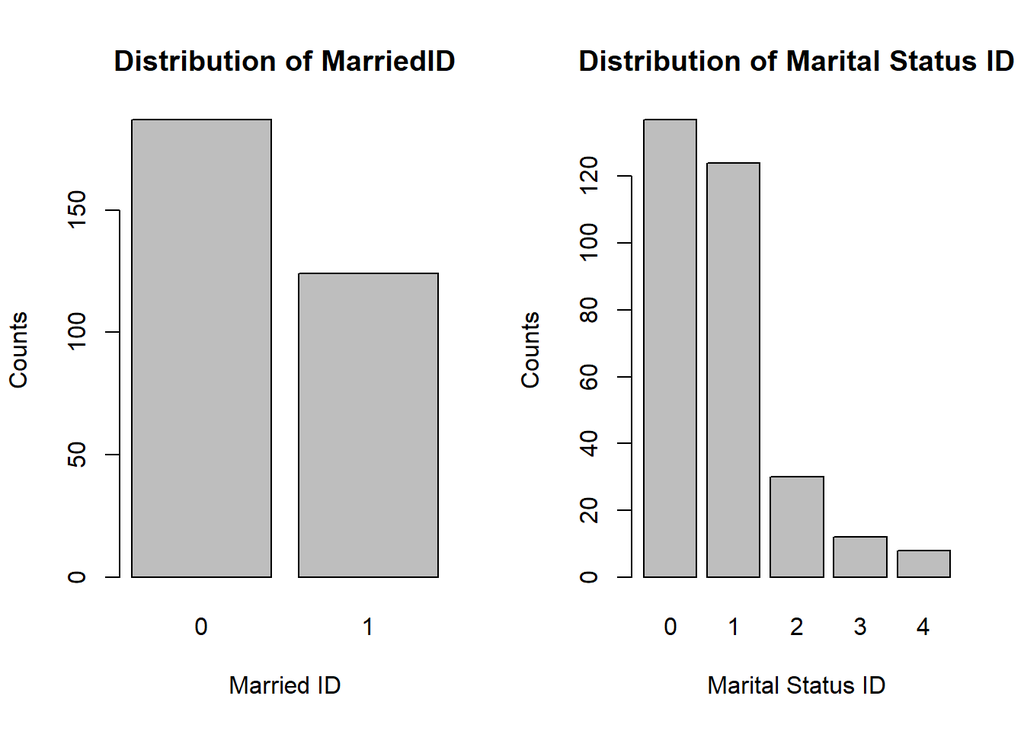

```r
par(mfrow=c(1,2))
freq.tbl_1 = table(hr$MarriedID)
barplot(freq.tbl_1, xlab="Married ID", ylab = "Counts", main="Distribution of MarriedID")
freq.tbl_2 = table(hr$MaritalStatusID)
barplot(freq.tbl_2, xlab="Marital Status ID", ylab = "Counts", main="Distribution of Marital Status ID")
```

- The graph on the left represents the Married ID. 0 indicates they are not married, and 1 indicates they are married.
- The graph on the right represents the Marital Status ID. 0 indicates Single, 1 indicates Married, 2 indicates Divorced, 3 indicates Separated, and 4 indicates Widowed.

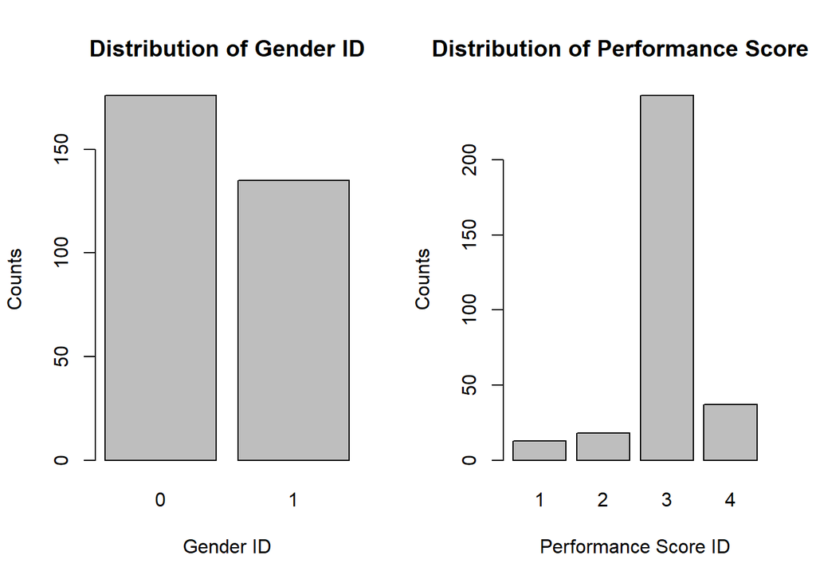

```r
par(mfrow=c(1,2))
freq.tbl_3 = table(hr$GenderID)
barplot(freq.tbl_3, xlab="Gender ID", ylab = "Counts", main="Distribution of Gender ID")
freq.tbl_6 = table(hr$PerfScoreID)
barplot(freq.tbl_6, xlab="Performance Score ID", ylab = "Counts", main="Distribution of Performance Score ID")
```

- The graph on the left represents the Gender ID. 0 indicates Female, and 1 indicates Male.
- The graph on the right represents the Performance Score ID. 1 indicates PIP, 2 indicates Needs Improvement, 3 indicates Fully Meets, and 4 indicates Exceeds.

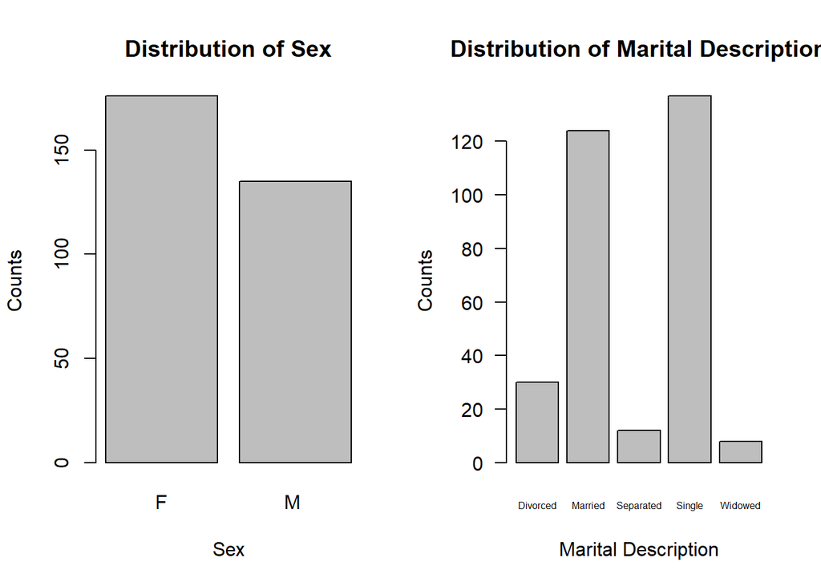

```r
par(mfrow=c(1,2))
freq.tbl_10 = table(hr$Sex)
barplot(freq.tbl_10, xlab="Sex", ylab = "Counts", main="Distribution of Sex")
freq.tbl_11 = table(hr$MaritalDesc)
barplot(freq.tbl_11, xlab="Marital Description", ylab = "Counts", main="Distribution of Marital Description", las = 1, cex.names = 0.5)
```

- The graph on the left represents the distribution of sex. F indicates Female, and M indicates Male.
- The graph on the right represents the marital description.

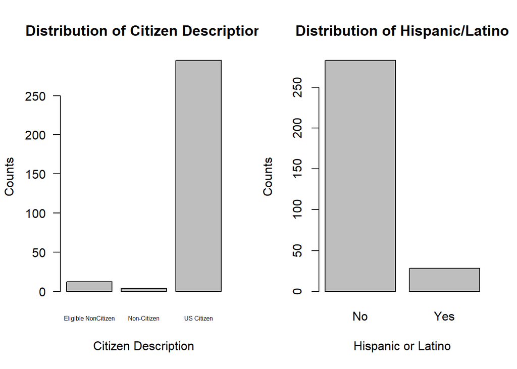

```r
par(mfrow=c(1,2))
freq.tbl_12 = table(hr$CitizenDesc)
barplot(freq.tbl_12, xlab="Citizen Description", ylab = "Counts", main="Distribution of Citizen Description", las = 1, cex.names = 0.5)
freq.tbl_13 = table(hr$HispanicLatino)
barplot(freq.tbl_13, xlab="Hispanic or Latino", ylab = "Counts", main="Distribution of Hispanic/Latino")
```

- The graph on the left represents the distribution of citizen description.
- The graph on the right represents the if the person is Hispanic or Latino or not.

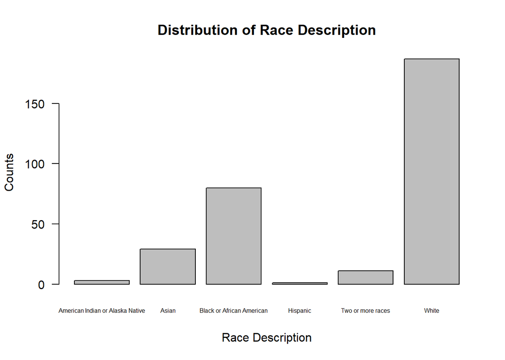

```r
freq.tbl_14 = table(hr$RaceDesc)
barplot(freq.tbl_14, xlab="Race Description", ylab = "Counts", main="Distribution of Race Description", las = 1, cex.names = 0.5)
```

- The graph above represents the race description.

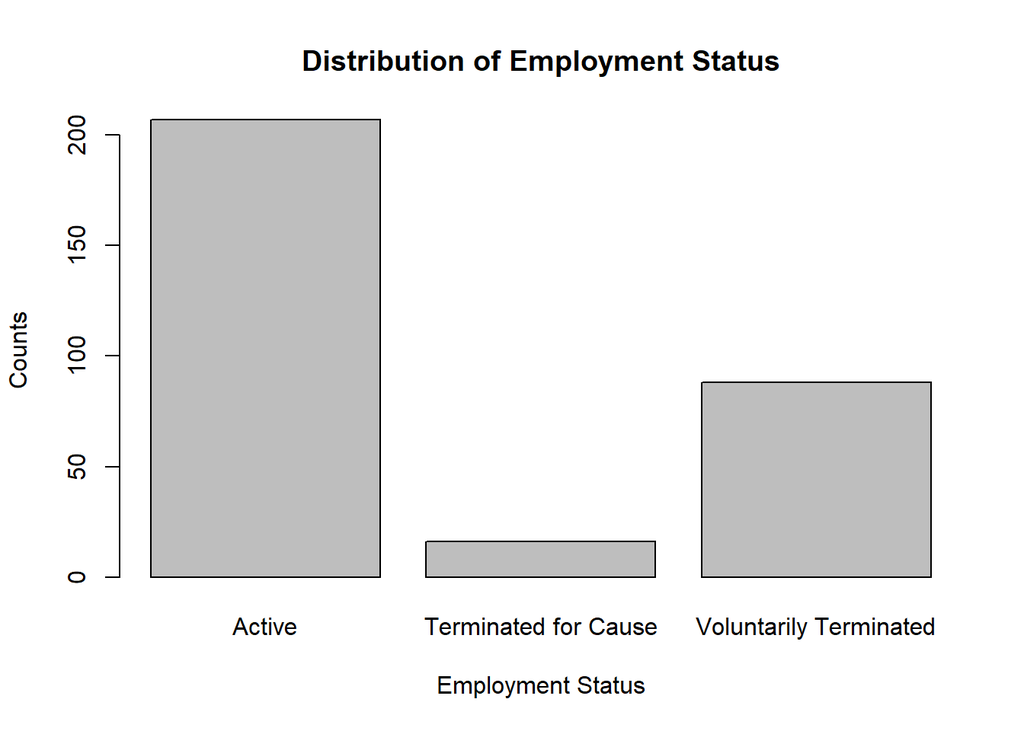

```r
freq.tbl_15 = table(hr$EmploymentStatus)
barplot(freq.tbl_15, xlab="Employment Status", ylab = "Counts", main="Distribution of Employment Status")
```

- The graph above represents the employment status.

```r
kable(as.data.frame(table(hr$TermReason)))
```

| Var1 | Freq |
| --- | --- |
| Another position | 20 |
| attendance | 7 |
| career change | 9 |
| Fatal attraction | 1 |
| gross misconduct | 1 |
| hours | 8 |
| Learned that he is a gangster | 1 |
| maternity leave - did not return | 3 |
| medical issues | 3 |
| military | 4 |
| more money | 11 |
| N/A-StillEmployed | 207 |
| no-call, no-show | 4 |
| performance | 4 |
| relocation out of area | 5 |
| retiring | 4 |
| return to school | 5 |
| unhappy | 14 |

- This is the frequency table to show the reason of termination.

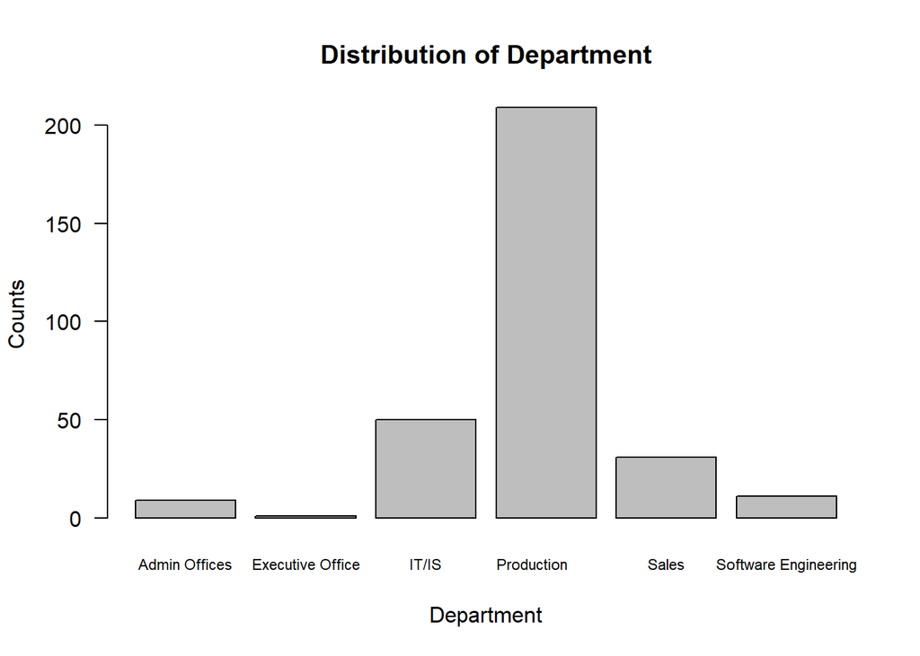

```r
freq.tbl_16 = table(hr$Department)
barplot(freq.tbl_16, xlab="Department", ylab = "Counts", main="Distribution of Department", las = 1, cex.names = 0.7)
```

- The graph above shows which department the person from.

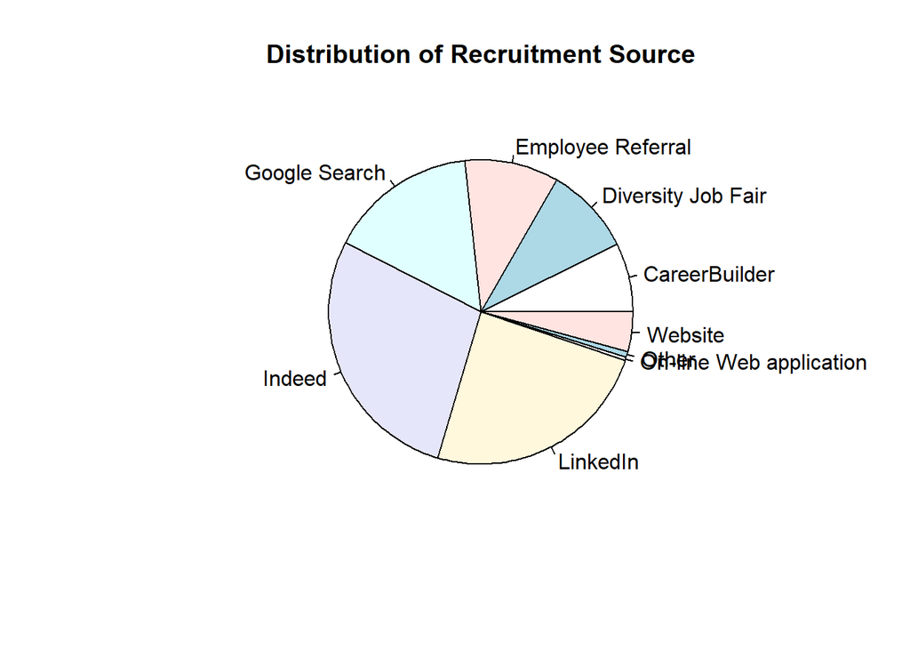

```r
Source = table(hr$RecruitmentSource)
pie(Source, main="Distribution of Recruitment Source")
```

- The pie chart above represents the distribution of recruitment source.

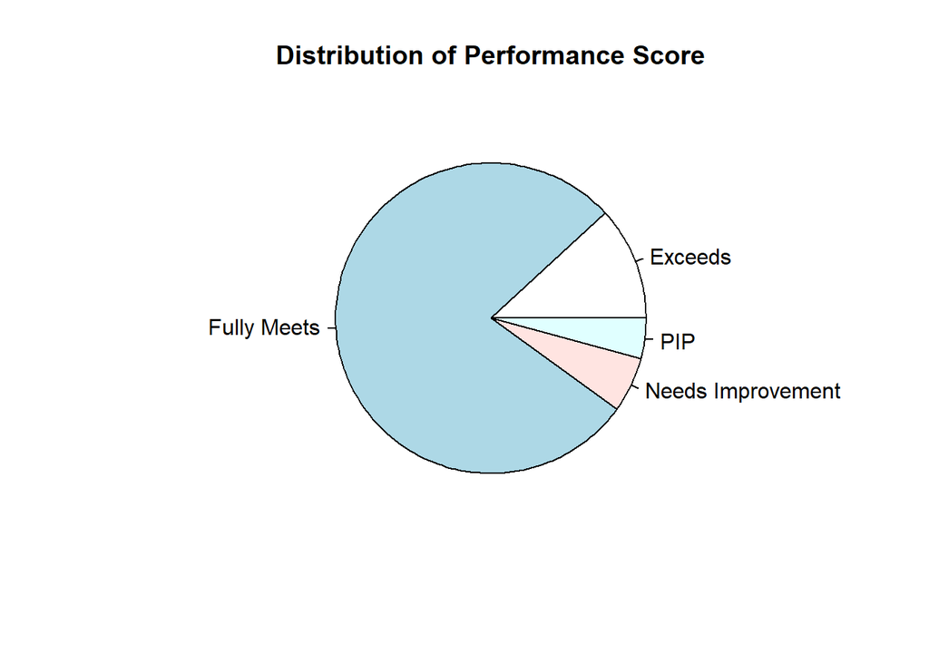

```r
Performance = table(hr$PerformanceScore)
pie(Performance, main="Distribution of Performance Score")
```

- The pie chart above represents the distribution of the performance score.

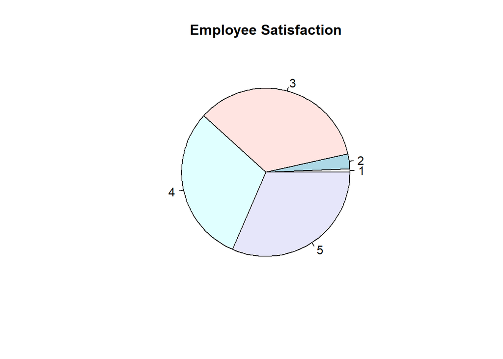

```r
Satis = table(hr$EmpSatisfaction)
pie(Satis, main="Employee Satisfaction")
```

*The pie chart above represents the employee satisfaction. From 1 is the lowest score and 5 is the highest score.

## 2.2 Summary of Numerical Variable

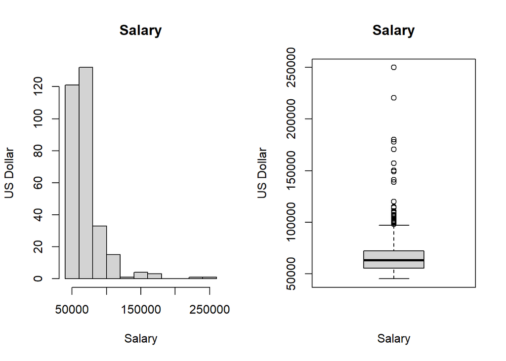

```r
par(mfrow=c(1,2))
hist(hr$Salary, xlab = "Salary", ylab = "US Dollar", main = "Salary")
boxplot(hr$Salary, xlab = "Salary", ylab = "US Dollar", main = "Salary")
```

- The histogram shows us the distribution of the salary for the employees. We can see that the diagram is heavily skewed to the right. That means most of the employees’ salary are between $50,000 to $100,000. When we look at the box plot, we see that there are a lot of outliers which means that those employees have so much higher salary than others. That means the median will be better representation for this data than mean.

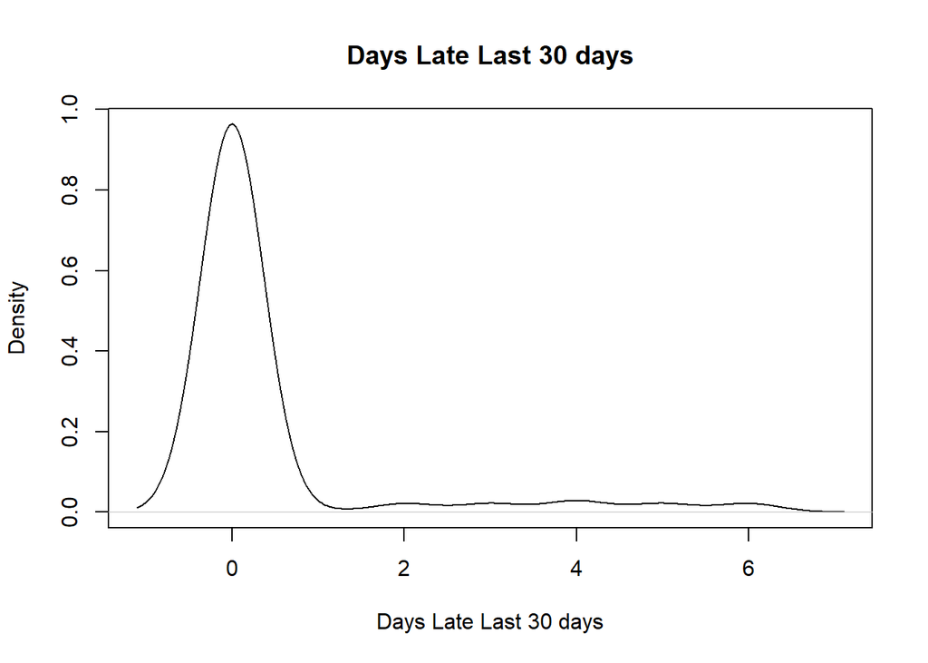

```r
den=density(hr$DaysLateLast30)
plot(den, xlab = "Days Late Last 30 days", ylab = "Density", main = "Days Late Last 30 days")
```

- When we look at this graph, it shows that most of the employees didn’t have any days late in last 30 days.

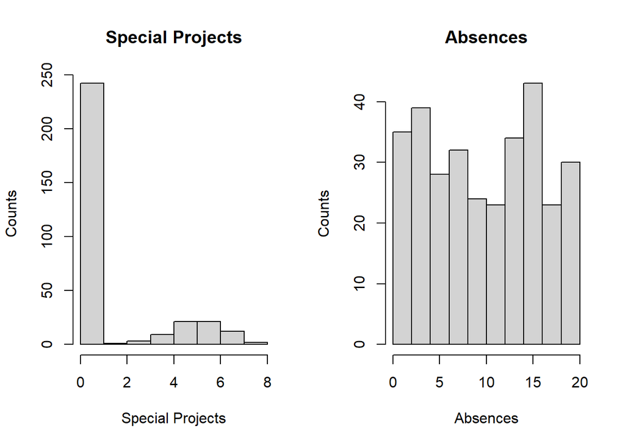

```r
par(mfrow=c(1,2))
hist(hr$SpecialProjectsCount, xlab = "Special Projects", ylab = "Counts", main = "Special Projects")
hist(hr$Absences, xlab = "Absences", ylab = "Counts", main = "Absences")
```

- The graph on the left shows that most of the employees have no special project.
- The graph on the right shows that the absences for the employees are equally distributed.

## 2.3 Two Variables

### 2.3.1 Salary and Absences

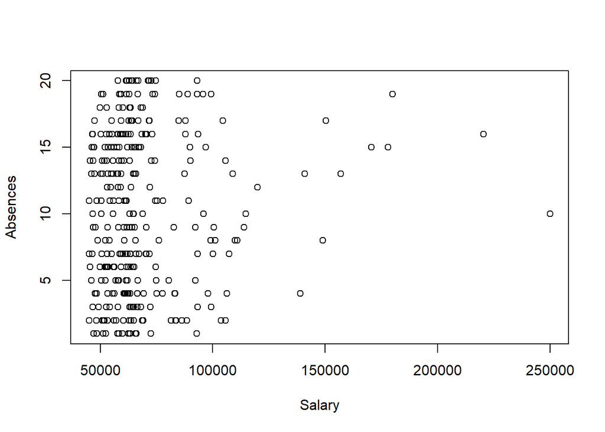

```r
plot(hr$Salary, hr$Absences, xlab = "Salary", ylab = "Absences")
```

- This plot shows us that the salary of the employee and the absences doesn’t have correlation.

### 2.3.2 Salary and Sex

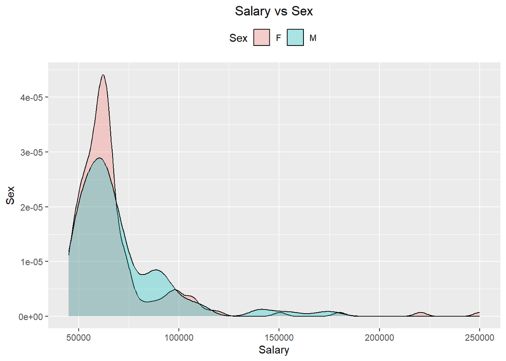

```r
ggplot(data = hr, aes(x = Salary, fill = Sex)) +
  geom_density(alpha = 0.3) +
  ggtitle("Salary vs Sex") +
  theme(plot.title = element_text(hjust = 0.5),
        legend.position="top") +
  xlab("Salary") +
  ylab("Sex")
```

### 2.3.3 Salary and Department

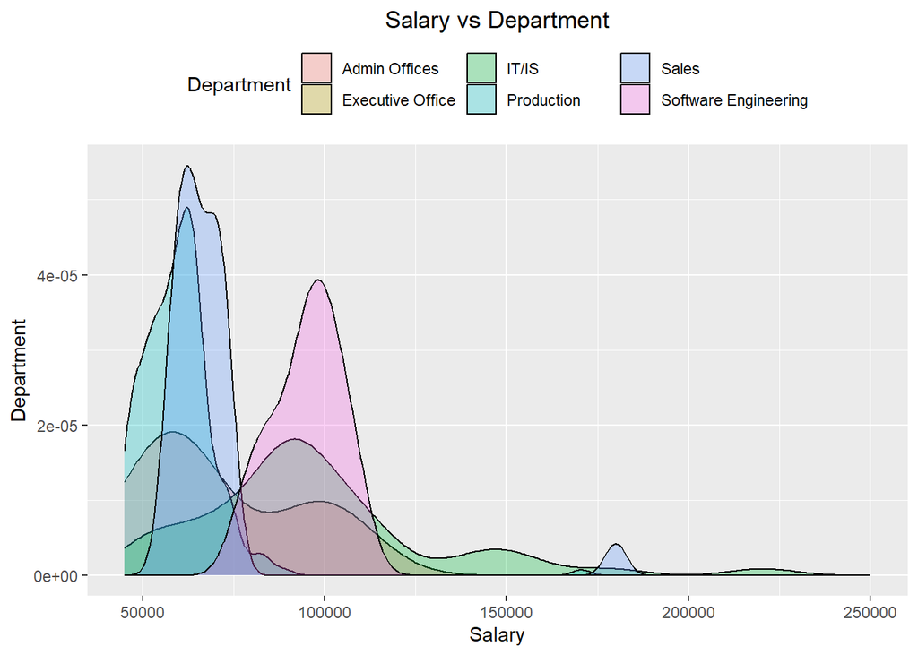

```r
ggplot(data = hr, aes(x = Salary, fill = Department)) +
  geom_density(alpha = 0.3) +
  ggtitle("Salary vs Department") +
  theme(plot.title = element_text(hjust = 0.5),
        legend.position="top") +
  xlab("Salary") +
  ylab("Department")
```

- From the ridge plot above shows that IT/IS and Software Engineering make more money than other department.

### 2.3.4 Salary and Race Description

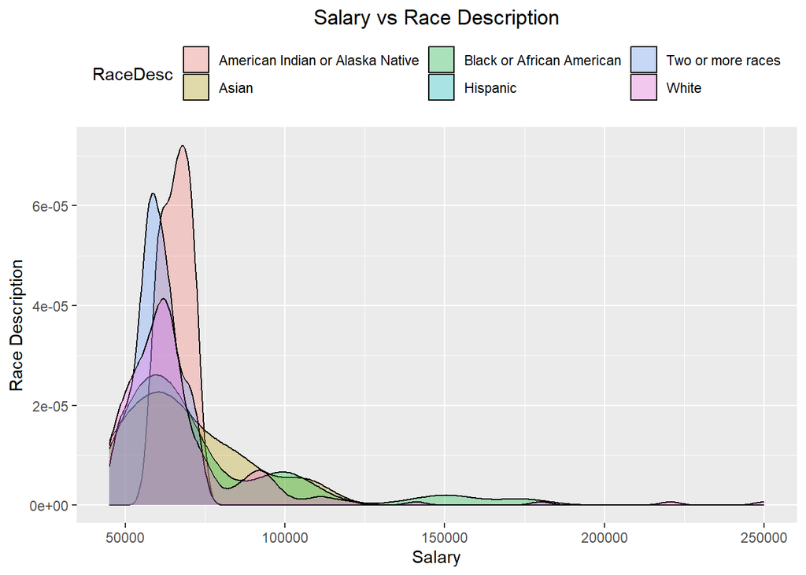

```r
ggplot(data = hr, aes(x = Salary, fill = RaceDesc)) +
  geom_density(alpha = 0.3) +
  ggtitle("Salary vs Race Description") +
  theme(plot.title = element_text(hjust = 0.5),
        legend.position="top") +
  xlab("Salary") +
  ylab("Race Description")
```

- The ridge plot above shows that the American Indian or Alaska Native makes around $70,000 and the other races make around $60,000.

# 3 Statistical Regression Modeling

## 3.1 Linear Regression Models

To find whether if there is a correlation between the variables Salary, Sex, Race Description and Department. The purpose of this analysis will be an association analysis. The data set has sufficient information to address the question.

- **Initial model**

The following initial model includes 3 predictor variables: Sex, Race Description, and Department. The residual plots demonstrate the following patterns.

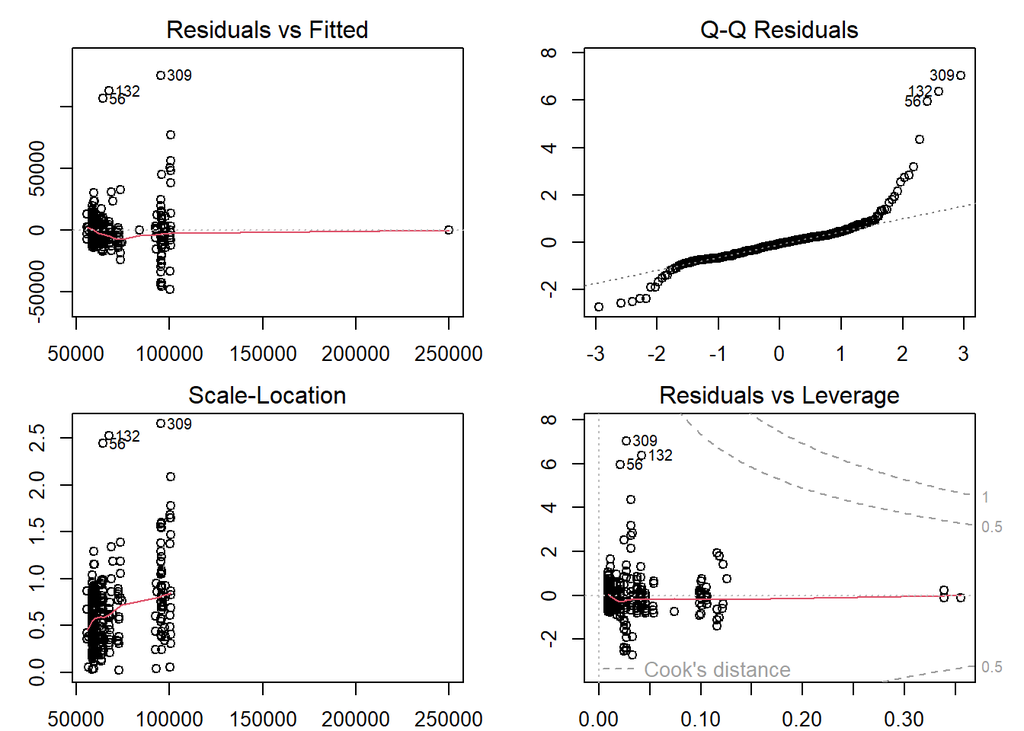

```r
ini.model = lm(Salary ~ Sex + RaceDesc + Department, data = hr)
par(mfrow=c(2,2), mar=c(2,3,2,2))
plot(ini.model)
```

Next, we will carry the Box-Cox transformation to identify a potential power transformation of the response variable: Salary.

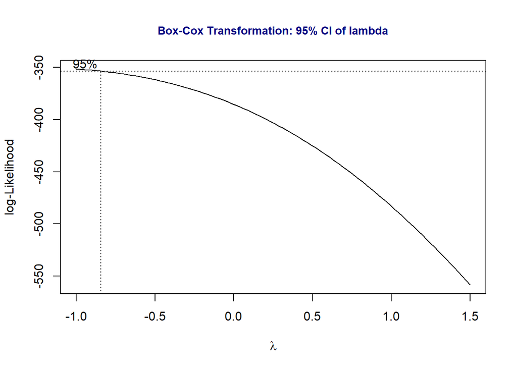

```r
library(MASS)
boxcox(Salary ~ Sex + RaceDesc + Department,
       data = hr,
       lambda = seq(-1, 1.5, length = 10),
       xlab=expression(paste(lambda)))
title(main = "Box-Cox Transformation: 95% CI of lambda",
      col.main = "navy", cex.main = 0.9)
```

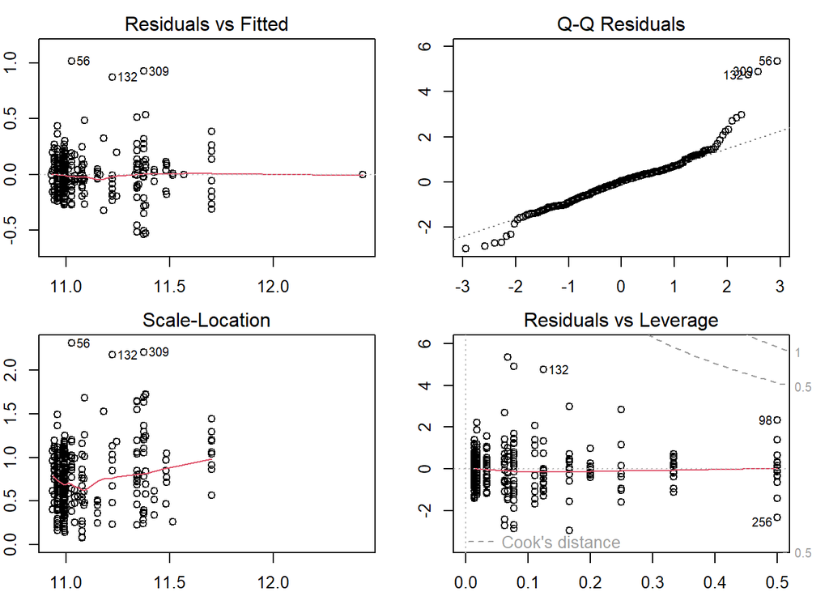

```r
transform.model = lm(log(Salary) ~ Sex * RaceDesc * Department , data  = hr)
par(mfrow=c(2,2), mar = c(2,2,2,2))
plot(transform.model)
```

The above residual plots indicate an improvement in model fit. We will use the transformed response to build the final model.

- **Final model**

The model based on the log-transformed response is summarized in the following.

```r
sum.trans = summary(transform.model)$coef
kable(sum.trans, caption = "Summarized statistics of the regression
      coefficients of the model with a log-transformed response")
```

Summarized statistics of the regression coefficients of the model with a log-transformed response

|  | Estimate | Std. Error | t value | Pr(>\|t\|) |
| --- | --- | --- | --- | --- |
| (Intercept) | 11.2465016 | 0.1984857 | 56.6615131 | 0.0000000 |
| SexM | 0.0862780 | 0.3228246 | 0.2672595 | 0.7894682 |
| RaceDescAsian | 0.0777662 | 0.2679667 | 0.2902083 | 0.7718740 |
| RaceDescBlack or African American | -0.1568000 | 0.2216291 | -0.7074885 | 0.4798577 |
| RaceDescHispanic | 0.2874682 | 0.2914571 | 0.9863139 | 0.3248398 |
| RaceDescTwo or more races | -0.2760004 | 0.2103759 | -1.3119392 | 0.1906269 |
| RaceDescWhite | -0.0645647 | 0.1412474 | -0.4571039 | 0.6479546 |
| DepartmentExecutive Office | 1.2472794 | 0.2415311 | 5.1640539 | 0.0000005 |
| DepartmentIT/IS | 0.1944468 | 0.1497912 | 1.2981187 | 0.1953263 |
| DepartmentProduction | -0.1896219 | 0.1412474 | -1.3424805 | 0.1805394 |
| DepartmentSales | 0.0433116 | 0.1559076 | 0.2778032 | 0.7813707 |
| DepartmentSoftware Engineering | 0.2439789 | 0.1800266 | 1.3552379 | 0.1764459 |
| SexM :RaceDescAsian | 0.1436304 | 0.2708405 | 0.5303137 | 0.5963193 |
| SexM :RaceDescBlack or African American | -0.1012490 | 0.3909349 | -0.2589918 | 0.7958339 |
| SexM :RaceDescTwo or more races | 0.1999075 | 0.3100215 | 0.6448181 | 0.5195787 |
| SexM :RaceDescWhite | -0.0223213 | 0.2555861 | -0.0873339 | 0.9304692 |
| SexM :DepartmentIT/IS | -0.0974751 | 0.2105086 | -0.4630456 | 0.6436953 |
| SexM :DepartmentProduction | -0.0960259 | 0.2001971 | -0.4796565 | 0.6318501 |
| SexM :DepartmentSales | -0.2120851 | 0.2241313 | -0.9462536 | 0.3448440 |
| SexM :DepartmentSoftware Engineering | -0.1395003 | 0.2670226 | -0.5224288 | 0.6017894 |
| RaceDescAsian:DepartmentIT/IS | -0.0319003 | 0.2604051 | -0.1225026 | 0.9025899 |
| RaceDescBlack or African American:DepartmentIT/IS | 0.1012146 | 0.1965762 | 0.5148874 | 0.6070423 |
| RaceDescAsian:DepartmentProduction | -0.1892974 | 0.2352702 | -0.8045959 | 0.4217430 |
| RaceDescBlack or African American:DepartmentProduction | 0.0936241 | 0.1759832 | 0.5320058 | 0.5951484 |
| RaceDescTwo or more races:DepartmentProduction | 0.1561844 | 0.1858363 | 0.8404405 | 0.4013863 |
| RaceDescAsian:DepartmentSales | -0.4545303 | 0.3259896 | -1.3943092 | 0.1643416 |
| RaceDescBlack or African American:DepartmentSales | -0.0892560 | 0.2044709 | -0.4365216 | 0.6627984 |
| RaceDescBlack or African American:DepartmentSoftware Engineering | 0.1815914 | 0.2481496 | 0.7317819 | 0.4649203 |
| SexM :RaceDescAsian:DepartmentIT/IS | -0.2480491 | 0.2009739 | -1.2342350 | 0.2181614 |
| SexM :RaceDescBlack or African American:DepartmentIT/IS | 0.4300014 | 0.3220737 | 1.3351026 | 0.1829390 |
| SexM :RaceDescBlack or African American:DepartmentProduction | 0.1446903 | 0.3042736 | 0.4755271 | 0.6347861 |
| SexM :RaceDescTwo or more races:DepartmentProduction | -0.1678775 | 0.2722296 | -0.6166761 | 0.5379549 |
| SexM :RaceDescBlack or African American:DepartmentSales | 0.3356955 | 0.3382393 | 0.9924791 | 0.3218300 |
| SexM :RaceDescBlack or African American:DepartmentSoftware Engineering | 0.1215397 | 0.3902884 | 0.3114100 | 0.7557232 |

```r
transform.model = lm(log(Salary)~Sex*RaceDesc*Department, data = hr)
final.model =  step(transform.model, direction = "forward", trace = 0)
backward.model =  step(transform.model, direction = "backward", trace = 0)
kable(summary(final.model)$coef, caption = "Summary statistics of the regression
      coefficients of the final model")
```

Summary statistics of the regression coefficients of the final model

|  | Estimate | Std. Error | t value | Pr(>\|t\|) |
| --- | --- | --- | --- | --- |
| (Intercept) | 11.2465016 | 0.1984857 | 56.6615131 | 0.0000000 |
| SexM | 0.0862780 | 0.3228246 | 0.2672595 | 0.7894682 |
| RaceDescAsian | 0.0777662 | 0.2679667 | 0.2902083 | 0.7718740 |
| RaceDescBlack or African American | -0.1568000 | 0.2216291 | -0.7074885 | 0.4798577 |
| RaceDescHispanic | 0.2874682 | 0.2914571 | 0.9863139 | 0.3248398 |
| RaceDescTwo or more races | -0.2760004 | 0.2103759 | -1.3119392 | 0.1906269 |
| RaceDescWhite | -0.0645647 | 0.1412474 | -0.4571039 | 0.6479546 |
| DepartmentExecutive Office | 1.2472794 | 0.2415311 | 5.1640539 | 0.0000005 |
| DepartmentIT/IS | 0.1944468 | 0.1497912 | 1.2981187 | 0.1953263 |
| DepartmentProduction | -0.1896219 | 0.1412474 | -1.3424805 | 0.1805394 |
| DepartmentSales | 0.0433116 | 0.1559076 | 0.2778032 | 0.7813707 |
| DepartmentSoftware Engineering | 0.2439789 | 0.1800266 | 1.3552379 | 0.1764459 |
| SexM :RaceDescAsian | 0.1436304 | 0.2708405 | 0.5303137 | 0.5963193 |
| SexM :RaceDescBlack or African American | -0.1012490 | 0.3909349 | -0.2589918 | 0.7958339 |
| SexM :RaceDescTwo or more races | 0.1999075 | 0.3100215 | 0.6448181 | 0.5195787 |
| SexM :RaceDescWhite | -0.0223213 | 0.2555861 | -0.0873339 | 0.9304692 |
| SexM :DepartmentIT/IS | -0.0974751 | 0.2105086 | -0.4630456 | 0.6436953 |
| SexM :DepartmentProduction | -0.0960259 | 0.2001971 | -0.4796565 | 0.6318501 |
| SexM :DepartmentSales | -0.2120851 | 0.2241313 | -0.9462536 | 0.3448440 |
| SexM :DepartmentSoftware Engineering | -0.1395003 | 0.2670226 | -0.5224288 | 0.6017894 |
| RaceDescAsian:DepartmentIT/IS | -0.0319003 | 0.2604051 | -0.1225026 | 0.9025899 |
| RaceDescBlack or African American:DepartmentIT/IS | 0.1012146 | 0.1965762 | 0.5148874 | 0.6070423 |
| RaceDescAsian:DepartmentProduction | -0.1892974 | 0.2352702 | -0.8045959 | 0.4217430 |
| RaceDescBlack or African American:DepartmentProduction | 0.0936241 | 0.1759832 | 0.5320058 | 0.5951484 |
| RaceDescTwo or more races:DepartmentProduction | 0.1561844 | 0.1858363 | 0.8404405 | 0.4013863 |
| RaceDescAsian:DepartmentSales | -0.4545303 | 0.3259896 | -1.3943092 | 0.1643416 |
| RaceDescBlack or African American:DepartmentSales | -0.0892560 | 0.2044709 | -0.4365216 | 0.6627984 |
| RaceDescBlack or African American:DepartmentSoftware Engineering | 0.1815914 | 0.2481496 | 0.7317819 | 0.4649203 |
| SexM :RaceDescAsian:DepartmentIT/IS | -0.2480491 | 0.2009739 | -1.2342350 | 0.2181614 |
| SexM :RaceDescBlack or African American:DepartmentIT/IS | 0.4300014 | 0.3220737 | 1.3351026 | 0.1829390 |
| SexM :RaceDescBlack or African American:DepartmentProduction | 0.1446903 | 0.3042736 | 0.4755271 | 0.6347861 |
| SexM :RaceDescTwo or more races:DepartmentProduction | -0.1678775 | 0.2722296 | -0.6166761 | 0.5379549 |
| SexM :RaceDescBlack or African American:DepartmentSales | 0.3356955 | 0.3382393 | 0.9924791 | 0.3218300 |
| SexM :RaceDescBlack or African American:DepartmentSoftware Engineering | 0.1215397 | 0.3902884 | 0.3114100 | 0.7557232 |

```r
r.ini.model = summary(ini.model)$r.squared
r.transfd.model = summary(transform.model)$r.squared
r.final.model = summary(final.model)$r.squared
r.backward.model = summary(backward.model)$r.squared
##
Rsquare = cbind(ini.model = r.ini.model, transfd.model = r.transfd.model, backward.model = r.backward.model,
                final.model = r.final.model)
kable(Rsquare, caption="Coefficients of correlation of the candidate model")
```

Coefficients of correlation of the candidate model

| ini.model | transfd.model | backward.model | final.model |
| --- | --- | --- | --- |
| 0.5039231 | 0.5426979 | 0.5082834 | 0.5426979 |

We used forward selection to choose the best model. The final model with the log transformation and forward selection: R^2 = 0.5427. This is the highest out of all models so we choose this as the final model.

```r
summary.final.model = summary(final.model)$coef
kable(summary.final.model, caption = "Summary of the final working model")
```

Summary of the final working model

|  | Estimate | Std. Error | t value | Pr(>\|t\|) |
| --- | --- | --- | --- | --- |
| (Intercept) | 11.2465016 | 0.1984857 | 56.6615131 | 0.0000000 |
| SexM | 0.0862780 | 0.3228246 | 0.2672595 | 0.7894682 |
| RaceDescAsian | 0.0777662 | 0.2679667 | 0.2902083 | 0.7718740 |
| RaceDescBlack or African American | -0.1568000 | 0.2216291 | -0.7074885 | 0.4798577 |
| RaceDescHispanic | 0.2874682 | 0.2914571 | 0.9863139 | 0.3248398 |
| RaceDescTwo or more races | -0.2760004 | 0.2103759 | -1.3119392 | 0.1906269 |
| RaceDescWhite | -0.0645647 | 0.1412474 | -0.4571039 | 0.6479546 |
| DepartmentExecutive Office | 1.2472794 | 0.2415311 | 5.1640539 | 0.0000005 |
| DepartmentIT/IS | 0.1944468 | 0.1497912 | 1.2981187 | 0.1953263 |
| DepartmentProduction | -0.1896219 | 0.1412474 | -1.3424805 | 0.1805394 |
| DepartmentSales | 0.0433116 | 0.1559076 | 0.2778032 | 0.7813707 |
| DepartmentSoftware Engineering | 0.2439789 | 0.1800266 | 1.3552379 | 0.1764459 |
| SexM :RaceDescAsian | 0.1436304 | 0.2708405 | 0.5303137 | 0.5963193 |
| SexM :RaceDescBlack or African American | -0.1012490 | 0.3909349 | -0.2589918 | 0.7958339 |
| SexM :RaceDescTwo or more races | 0.1999075 | 0.3100215 | 0.6448181 | 0.5195787 |
| SexM :RaceDescWhite | -0.0223213 | 0.2555861 | -0.0873339 | 0.9304692 |
| SexM :DepartmentIT/IS | -0.0974751 | 0.2105086 | -0.4630456 | 0.6436953 |
| SexM :DepartmentProduction | -0.0960259 | 0.2001971 | -0.4796565 | 0.6318501 |
| SexM :DepartmentSales | -0.2120851 | 0.2241313 | -0.9462536 | 0.3448440 |
| SexM :DepartmentSoftware Engineering | -0.1395003 | 0.2670226 | -0.5224288 | 0.6017894 |
| RaceDescAsian:DepartmentIT/IS | -0.0319003 | 0.2604051 | -0.1225026 | 0.9025899 |
| RaceDescBlack or African American:DepartmentIT/IS | 0.1012146 | 0.1965762 | 0.5148874 | 0.6070423 |
| RaceDescAsian:DepartmentProduction | -0.1892974 | 0.2352702 | -0.8045959 | 0.4217430 |
| RaceDescBlack or African American:DepartmentProduction | 0.0936241 | 0.1759832 | 0.5320058 | 0.5951484 |
| RaceDescTwo or more races:DepartmentProduction | 0.1561844 | 0.1858363 | 0.8404405 | 0.4013863 |
| RaceDescAsian:DepartmentSales | -0.4545303 | 0.3259896 | -1.3943092 | 0.1643416 |
| RaceDescBlack or African American:DepartmentSales | -0.0892560 | 0.2044709 | -0.4365216 | 0.6627984 |
| RaceDescBlack or African American:DepartmentSoftware Engineering | 0.1815914 | 0.2481496 | 0.7317819 | 0.4649203 |
| SexM :RaceDescAsian:DepartmentIT/IS | -0.2480491 | 0.2009739 | -1.2342350 | 0.2181614 |
| SexM :RaceDescBlack or African American:DepartmentIT/IS | 0.4300014 | 0.3220737 | 1.3351026 | 0.1829390 |
| SexM :RaceDescBlack or African American:DepartmentProduction | 0.1446903 | 0.3042736 | 0.4755271 | 0.6347861 |
| SexM :RaceDescTwo or more races:DepartmentProduction | -0.1678775 | 0.2722296 | -0.6166761 | 0.5379549 |
| SexM :RaceDescBlack or African American:DepartmentSales | 0.3356955 | 0.3382393 | 0.9924791 | 0.3218300 |
| SexM :RaceDescBlack or African American:DepartmentSoftware Engineering | 0.1215397 | 0.3902884 | 0.3114100 | 0.7557232 |

In summary, Department Executive Office is statistically significant (p-value < alpha = 0.05). The model has a R^2 = 0.54 which indicates medium correlation between the response variable and the explanatory variables.

## 3.2 Logistic Regression Analysis

The purpose of this logistic regression analysis is to find out if we can use the predictor variables to predict our response variable: Salary. The purpose of this analysis will be a predictive analysis. We will create a new variable called SalaryID.

The response variable: SalaryID - It shows the salary of the employees in US Dollar. 0 indicates the employee’s salary is below the median = 62810, and 1 indicates the employee’s salary is above median.

Predictor variables:

- Sex
- Department
- Hispanic or Latino
- Marital Description
- Citizen Description
- Race Description
- Absences
- Days Late Last 30 Days
- Engagement Survey

Here below we are trying to build the initial model.

- **Build an Initial Model**

```r
library(dplyr)
hr <- hr %>%
  mutate(SalaryID = ifelse(Salary >= 62810, 1, 0))
```

```r
initial.model = glm(SalaryID ~ Sex + Department  + HispanicLatino + MaritalDesc + CitizenDesc
                    + RaceDesc + Absences + DaysLateLast30 + EngagementSurvey, family = binomial, data = hr)
coefficient.table = summary(initial.model)$coef
kable(coefficient.table, caption = "Significance tests of logistic regression model")
```

Significance tests of logistic regression model

|  | Estimate | Std. Error | z value | Pr(>\|z\|) |
| --- | --- | --- | --- | --- |
| (Intercept) | 1.1038576 | 1.8884005 | 0.5845463 | 0.5588528 |
| SexM | 0.1715104 | 0.2680277 | 0.6398981 | 0.5222388 |
| DepartmentExecutive Office | 16.5057654 | 2399.5448905 | 0.0068787 | 0.9945116 |
| DepartmentIT/IS | 1.3110244 | 0.8535759 | 1.5359201 | 0.1245580 |
| DepartmentProduction | -1.3465674 | 0.7456661 | -1.8058584 | 0.0709405 |
| DepartmentSales | -0.0125237 | 0.8438024 | -0.0148420 | 0.9881583 |
| DepartmentSoftware Engineering | 15.7842925 | 703.0565709 | 0.0224510 | 0.9820882 |
| HispanicLatinoYes | -0.6363223 | 0.5017478 | -1.2682113 | 0.2047225 |
| MaritalDescMarried | -0.0478748 | 0.4562144 | -0.1049393 | 0.9164239 |
| MaritalDescSeparated | 0.2087134 | 0.7484563 | 0.2788585 | 0.7803534 |
| MaritalDescSingle | -0.0654717 | 0.4574959 | -0.1431088 | 0.8862042 |
| MaritalDescWidowed | 0.0028609 | 0.8660202 | 0.0033036 | 0.9973642 |
| CitizenDescNon-Citizen | 1.3242390 | 1.4191403 | 0.9331276 | 0.3507541 |
| CitizenDescUS Citizen | -0.0904698 | 0.6881138 | -0.1314751 | 0.8953995 |
| RaceDescAsian | -0.4619598 | 1.3799942 | -0.3347549 | 0.7378100 |
| RaceDescBlack or African American | -0.9239798 | 1.3290693 | -0.6952082 | 0.4869249 |
| RaceDescHispanic | 17.0236034 | 2399.5451438 | 0.0070945 | 0.9943394 |
| RaceDescTwo or more races | -1.3662153 | 1.4816042 | -0.9221190 | 0.3564665 |
| RaceDescWhite | -0.9641814 | 1.3170498 | -0.7320767 | 0.4641218 |
| Absences | 0.0316628 | 0.0227559 | 1.3914065 | 0.1641022 |
| DaysLateLast30 | -0.1003730 | 0.1276863 | -0.7860904 | 0.4318146 |
| EngagementSurvey | 0.0783988 | 0.2067862 | 0.3791297 | 0.7045915 |

- **Automatic Variable Selection**

We assume Department, Engagement Survey, and Absences are practically important, we want to include these three variables in the final model regardless of their statistical significance.

In summary, we define two models: the full model and the reduced model. The final best model will be the model between the full and reduced models. The summary table of significant tests is given below.

```r
full.model = initial.model
reduced.model = glm(SalaryID ~  + Department + EngagementSurvey + Absences , family = binomial, data = hr)
final.model =  step(full.model,
                    scope=list(lower=formula(reduced.model),upper=formula(full.model)),
                    data = hr,
                    direction = "backward",
                    trace = 0)
final.model.coef = summary(final.model)$coef
kable(final.model.coef , caption = "Summary table of significant tests")
```

Summary table of significant tests

|  | Estimate | Std. Error | z value | Pr(>\|z\|) |
| --- | --- | --- | --- | --- |
| (Intercept) | -0.1903112 | 1.0245827 | -0.1857451 | 0.8526447 |
| DepartmentExecutive Office | 15.7693092 | 2399.5448257 | 0.0065718 | 0.9947565 |
| DepartmentIT/IS | 1.3009941 | 0.8343218 | 1.5593433 | 0.1189151 |
| DepartmentProduction | -1.3012864 | 0.7257428 | -1.7930409 | 0.0729664 |
| DepartmentSales | -0.0798713 | 0.8115528 | -0.0984178 | 0.9216005 |
| DepartmentSoftware Engineering | 15.9214354 | 721.4003563 | 0.0220702 | 0.9823920 |
| Absences | 0.0257803 | 0.0218961 | 1.1773905 | 0.2390397 |
| EngagementSurvey | 0.1509871 | 0.1638893 | 0.9212754 | 0.3569067 |

- **Interpretation - Predictive analysis**

The summary table contains the three practically important variables Department, Engagement Survey, and Absences. We used backward selection to choose the best model. However, all of the variables do not achieve statistical significance. The p-value of Department IT/IS and Department Production have a smaller value than the other variables but they are still higher than alpha = 0.05. Department: IT/IS is positively associated with the response variable. Department: Production is negatively associated with the response variable.

In summary, this logistic regression model analysis cannot find the employee’s salary is above or below median based on the department, engagement survey, and absences because all the p-value of the variables are not statistically significant.

# 4 Predictive Modeling

## 4.1 Prediction Linear Regression

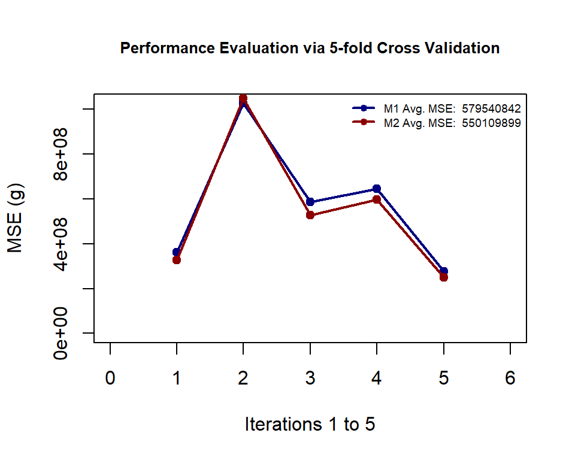

Cross-validation for evaluating predictive performance of linear regression models

```r
hr_clean = na.omit(hr)  # delete all records with missing values
##
n = dim(hr_clean)[1]     # sample size
obs.ID = 1:n            # randomize obs ID
n.train = round(0.8*n)  # training data size

shuffled.id = sample(obs.ID,
                          n,
                          replace = FALSE)  # randomizing the observation IDs
shuffled.hr = na.omit(hr_clean[shuffled.id, ])   # randomizing the data set
# Two-way split for training and testing data sets
train.data = shuffled.hr[1:n.train,]         # training data
test.data = shuffled.hr[(n.train + 1):n, ]   # testing data
##
n.fold = round(n.train/5)-1    # size of 5-fold splitting, -1 to guarantee that
                               # 5*foldsize <= train.data size
## 5-fold cross-validation: iterative process with a for-loop
##
MSE.M1 = rep(0,5)
MSE.M2 = rep(0,5)
##
for (i in 1:5){
  valid.id = ((i-1)*n.fold+1):(i*n.fold)    # obs ID for validating fold
  cross.train = train.data[-valid.id, ]
  cross.valid = train.data[valid.id,]
  ## Building the two models
  M1 = lm(Salary ~ PositionID + DeptID  , data  = cross.train)
  M2 = lm(Salary ~PositionID +  DeptID + ManagerID, data  = cross.train)
  ## Predicting bodyMass with validate fold
  predM1 = predict(M1, newdata = cross.valid)
  predM2 = predict(M2, newdata = cross.valid)
  ##
  MSE.M1[i] = mean((predM1 - cross.valid$Salary)^2)
  MSE.M2[i] = mean((predM2 - cross.valid$Salary)^2)
 }
 MSE.1 = mean(MSE.M1)
 MSE.2 = mean(MSE.M2)
 ### Visualize the MSE
 plot(1:5, MSE.M1, type = "l",
      xlim =c(0,6),
      ylim = c(100000, 50000+max(MSE.M1)),
      ylab = "MSE (g)",
      xlab = "Iterations 1 to 5",
      lwd = 2,
      col = "navy",
      main = "Performance Evaluation via 5-fold Cross Validation",
      cex.main = 0.8)
 points(1:5, MSE.M1, pch = 19, col = "navy")
 lines(1:5, MSE.M2, lwd = 2, col = "darkred")
 points(1:5, MSE.M2, pch = 19, col = "darkred")
 legend("topright", c(paste("M1 Avg. MSE: ", round(MSE.1)), paste("M2 Avg. MSE: ",round(MSE.2))),
        col=c("navy", "darkred"),
        pch = rep(19,2),
        lwd = rep(2,2),
        cex = 0.6,
        bty = "n")
```

```r
M2.final = lm(Salary ~PositionID +  DeptID + ManagerID, data  = train.data)
predM2.final = predict(M2.final, newdata = test.data)
MSE.M2.final = mean((predM2.final - test.data$Salary)^2)
MSE.M2.final
```

```
[1] 406138314
```

The actual performance of the recommended model has mean squared error (MSE) is shown above.

## 4.2 Logistic Predictive Modeling

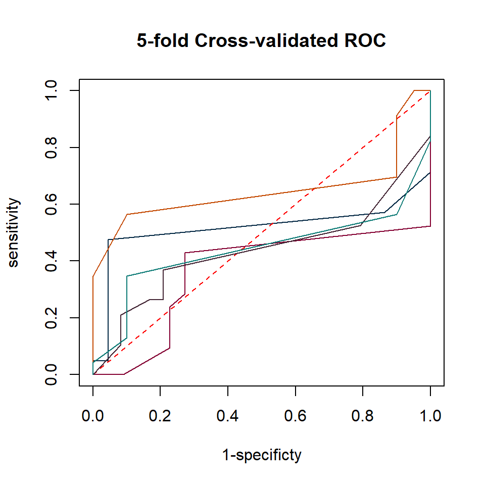

```r
nn = dim(hr)[1]
train.id = sample(1:nn, round(nn*0.7), replace = FALSE)
trainDat = hr[train.id,]
testDat = hr[-train.id,]
## each fold has 2326 observations
##
AUC.vec = rep(0,5)
color=c("#002642","#840032","#432534", "#c44900", "#0b7a75")
##
for(i in 1:5){
  ID = ((i-1)*43+1):(i*43)
  valid = as.data.frame(trainDat[ID,])
  train = as.data.frame(trainDat[-ID,])
  ##
  logit.model = glm(SalaryID ~ PositionID, family = binomial(link = logit), data = hr)
  newdata = data.frame(PositionID = valid$PositionID)
  pred.prob.train = predict.glm(logit.model, newdata, type = "response")
  ## we next use library {pROC}
  ## to calculate AUC
  prediction = pred.prob.train
  category = valid$SalaryID == 1
  ROCobj <- roc(category, prediction)
  AUC.vec[i] = round(auc(ROCobj),4)
  if(i==1){
    plot((1-ROCobj$specificities),ROCobj$sensitivities,
         type="l",
         main="5-fold Cross-validated ROC",
         col=color[i],
         xlab="1-specificty",
         ylab="sensitivity",
         lwd=1,
         lty=1)
        segments(0,0,1,1, lty=2, col="red")
    } else{
    lines((1-ROCobj$specificities),ROCobj$sensitivities, col=color[i], lwd=1)
    }
}
```

```r
summary(AUC.vec)
```

```
   Min. 1st Qu.  Median    Mean 3rd Qu.    Max.
 0.3647  0.4386  0.4435  0.4826  0.5184  0.6478
```

## 4.3 Testing Performance

We will calculate the UC based on the hold-out testing data.

```r
  logit.model = glm(SalaryID ~ PositionID, family = binomial(link = logit), data = hr)

  ###
  newdata = data.frame(PositionID = testDat$PositionID)
  pred.prob.train = predict.glm(logit.model, newdata, type = "response")
  ## we next use library {pROC}
  ## to calculate AUC
  prediction = pred.prob.train
  category = testDat$SalaryID == 1
  ROCobj <- roc(category, prediction)
  testAUC= round(auc(ROCobj),4)
  c(testAUC = testAUC)
```

```
testAUC
 0.6341
```